# Image_processing

## Image processing

### Looking at cv2 and matplotlibs feature definitions

We will look at different of features of a leaf that can be outlined by python modules.

Even though it would seem intuitive that leaf shape would be the best defining characteristic for defining one species from another, it is not. One of the most important features to look at is leaf vein pattern (venation) and surface texture such as waxy leaves can help identify plant from plant.

```python
# We import our modules CV2 and Matplotlib.
# Images are processed by cv2.

import cv2
%matplotlib inline

import numpy as np
pic ='/media/boots_wine/DATA/Data_Analytics/College_projects/Data_mining/Plants/Images/Different_styles/hcn.000002.jpg'
img =cv2.imread(pic)

ret,thresh_img = cv2.threshold(img,127,255,cv2.THRESH_BINARY)
cv2.imwrite('/media/boots_wine/DATA/Data_Analytics/College_projects/Data_mining/Plants/Images/Different_styles/threshold_hcn.jpg',thresh_img)
```

```
True
```

### Original, Grayed and thresholded

The images below consist of normal (coloured), grey and then a threshold filter is applied

The cv2.threshold allows the pixels to be removed due to lighting value given to them. This is of great help, only when the image is a uniform photo without external factors influencing the lighting.

This helps the venation pattern to become more shaper, helping the algorithm to identify venation.

```python
#pic_gray = cv2.imread(pic, cv2.IMREAD_GRAYSCALE), (IMG_SIZE, IMG_SIZE)
img = cv2.resize(cv2.imread(pic, cv2.IMREAD_GRAYSCALE), (640, 594))
cv2.imwrite('/media/boots_wine/DATA/Data_Analytics/College_projects/Data_mining/Plants/Images/Different_styles/grayscale_hcn.jpg',img)

ret,thresh_img = cv2.threshold(img,127,255,cv2.THRESH_BINARY)
cv2.imwrite('/media/boots_wine/DATA/Data_Analytics/College_projects/Data_mining/Plants/Images/Different_styles/bw_grayscale_hcn.jpg',thresh_img)
```

```
True
```

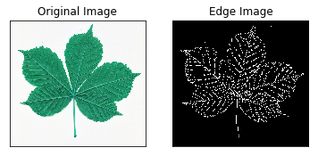

```python
import cv2
import numpy as np
from matplotlib import pyplot as plt

img = cv2.imread('/media/boots_wine/DATA/Data_Analytics/College_projects/Data_mining/Plants/Images/Different_styles/hcn.000002.jpg')
edges = cv2.Canny(img,100,200)

plt.subplot(121),plt.imshow(img,cmap = 'gray')
plt.title('Original Image'), plt.xticks([]), plt.yticks([])
plt.subplot(122),plt.imshow(edges,cmap = 'gray')
plt.title('Edge Image'), plt.xticks([]), plt.yticks([])

plt.show()
```

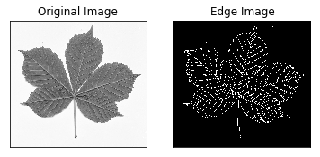

```python
import cv2
import numpy as np
from matplotlib import pyplot as plt

img = cv2.imread('/media/boots_wine/DATA/Data_Analytics/College_projects/Data_mining/Plants/Images/Different_styles/hcn.000002.jpg',0)
edges = cv2.Canny(img,100,200)

plt.subplot(121),plt.imshow(img,cmap = 'gray')
plt.title('Original Image'), plt.xticks([]), plt.yticks([])
plt.subplot(122),plt.imshow(edges,cmap = 'gray')
plt.title('Edge Image'), plt.xticks([]), plt.yticks([])

plt.show()
```

### Image gradients

Images have been processed with two image gradient formulas.

The Laplacian defines the edges. The image shows the spatial outline in a rather static manner.

The Sobel formula defines edges along the X and Y-axises. The image comparatively to the Laplacian is less effected with noise and appears more defined.

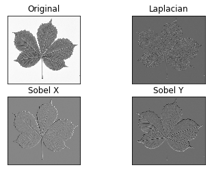

```python
import cv2
import numpy as np
from matplotlib import pyplot as plt

img = cv2.imread('/media/boots_wine/DATA/Data_Analytics/College_projects/Data_mining/Plants/Images/Different_styles/hcn.000002.jpg',0)

laplacian = cv2.Laplacian(img,cv2.CV_64F)
sobelx = cv2.Sobel(img,cv2.CV_64F,1,0,ksize=5)
sobely = cv2.Sobel(img,cv2.CV_64F,0,1,ksize=5)

plt.subplot(2,2,1),plt.imshow(img,cmap = 'gray')
plt.title('Original'), plt.xticks([]), plt.yticks([])
plt.subplot(2,2,2),plt.imshow(laplacian,cmap = 'gray')
plt.title('Laplacian'), plt.xticks([]), plt.yticks([])
plt.subplot(2,2,3),plt.imshow(sobelx,cmap = 'gray')
plt.title('Sobel X'), plt.xticks([]), plt.yticks([])
plt.subplot(2,2,4),plt.imshow(sobely,cmap = 'gray')
plt.title('Sobel Y'), plt.xticks([]), plt.yticks([])

plt.show()
```

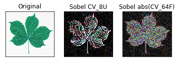

```python
import cv2
import numpy as np
from matplotlib import pyplot as plt

img = cv2.imread('/media/boots_wine/DATA/Data_Analytics/College_projects/Data_mining/Plants/Images/Different_styles/hcn.000002.jpg')

# Output dtype = cv2.CV_8U
sobelx8u = cv2.Sobel(img,cv2.CV_8U,1,0,ksize=5)

# Output dtype = cv2.CV_64F. Then take its absolute and convert to cv2.CV_8U
sobelx64f = cv2.Sobel(img,cv2.CV_64F,1,0,ksize=5)
abs_sobel64f = np.absolute(sobelx64f)
sobel_8u = np.uint8(abs_sobel64f)

plt.subplot(1,3,1),plt.imshow(img,cmap = 'gray')
plt.title('Original'), plt.xticks([]), plt.yticks([])
plt.subplot(1,3,2),plt.imshow(sobelx8u,cmap = 'gray')
plt.title('Sobel CV_8U'), plt.xticks([]), plt.yticks([])
plt.subplot(1,3,3),plt.imshow(sobel_8u,cmap = 'gray')
plt.title('Sobel abs(CV_64F)'), plt.xticks([]), plt.yticks([])

plt.show()
```

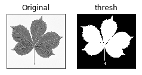

```python
#Image Segmentation with Watershed Algorithm

import numpy as np
import cv2
from matplotlib import pyplot as plt

gray = cv2.imread('/media/boots_wine/DATA/Data_Analytics/College_projects/Data_mining/Plants/Images/Different_styles/hcn.000002.jpg',0)
ret, thresh = cv2.threshold(gray,0,255,cv2.THRESH_BINARY_INV+cv2.THRESH_OTSU)

plt.subplot(1,3,1),plt.imshow(gray,cmap = 'gray')
plt.title('Original'), plt.xticks([]), plt.yticks([])
plt.subplot(1,3,2),plt.imshow(thresh,cmap = 'gray')
plt.title('thresh'), plt.xticks([]), plt.yticks([])

plt.show()
```

### Removing noise.

We reduce the noise and print the out the images.

We can see that the original image has nearly disappeared as the noise was removed alongside most of them image. Only leaving a segment. When we reverse it, so that the noisy parts of the image remain, we are left with a more intact image of the leaf

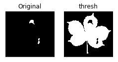

```python
# noise removal
kernel = np.ones((3,3),np.uint8)
opening = cv2.morphologyEx(thresh,cv2.MORPH_OPEN,kernel, iterations = 2)

# sure background area
sure_bg = cv2.dilate(opening,kernel,iterations=3)

# Finding sure foreground area
dist_transform = cv2.distanceTransform(opening,cv2.DIST_L2,5)
ret, sure_fg = cv2.threshold(dist_transform,0.7*dist_transform.max(),255,0)

# Finding unknown region
sure_fg = np.uint8(sure_fg)
unknown = cv2.subtract(sure_bg,sure_fg)


plt.subplot(1,3,1),plt.imshow(sure_fg,cmap = 'gray')
plt.title('Original'), plt.xticks([]), plt.yticks([])
plt.subplot(1,3,2),plt.imshow(unknown,cmap = 'gray')
plt.title('thresh'), plt.xticks([]), plt.yticks([])

plt.show()
```

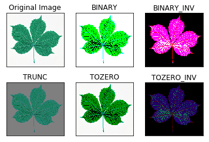

```python
import cv2
import numpy as np
from matplotlib import pyplot as plt

img = cv2.imread('/media/boots_wine/DATA/Data_Analytics/College_projects/Data_mining/Plants/Images/Different_styles/hcn.000002.jpg')
ret,thresh1 = cv2.threshold(img,127,255,cv2.THRESH_BINARY)
ret,thresh2 = cv2.threshold(img,127,255,cv2.THRESH_BINARY_INV)
ret,thresh3 = cv2.threshold(img,127,255,cv2.THRESH_TRUNC)
ret,thresh4 = cv2.threshold(img,127,255,cv2.THRESH_TOZERO)
ret,thresh5 = cv2.threshold(img,127,255,cv2.THRESH_TOZERO_INV)

titles = ['Original Image','BINARY','BINARY_INV','TRUNC','TOZERO','TOZERO_INV']
images = [img, thresh1, thresh2, thresh3, thresh4, thresh5]

for i in range(6):
    plt.subplot(2,3,i+1),plt.imshow(images[i],'gray')
    plt.title(titles[i])
    plt.xticks([]),plt.yticks([])

plt.show()
```